```
---
title: "Comparison of WT vs KO AOM_DSS mouse model"
author: Anne Hartebrodt
date: "09.01.2024"
output:
  html_document:
    number_sections: true
---
```

# ZEB1 differential abundance analysis of myCAF and iCAF like phenotypes.

The goal of this analysis is to elucidate if there is a change in cell type composition between the two conditions. We will use integrated clustering and differential abundance analysis.

```r
knitr::opts_chunk$set(message = FALSE, warning = FALSE, echo=TRUE, include=TRUE)
```

```r
require(scater)
require(scran)
require(Seurat)
require(stringr)
require(patchwork)
require(DAseq)
require(harmony)
require(data.table)
require(dplyr)
require(decoupleR)
library(dorothea)
library(dplyr)
library(tibble)
library(tidyr)
library(patchwork)
library(ggplot2)
library(pheatmap)
```

## Reproduction setup

### Input files

In order to use this notebook please note that you should create an analysis folder with a subdirectory `data`. In the course of the notebook execution a results folder with various subdirectories will be created automatically and an html version of the notebook will be created in the directory where you execute this notebook.

```r
## Your fully qualified base directory.
analysis_dir<-'~/Documents/external_analyses/marc_stemmler/'
data_dir<-file.path(analysis_dir, 'data')

input_data<-file.path(data_dir, 'merged.rescaled2.RData')
marker_file<-file.path(data_dir, 'marker_genes.tsv.csv')
```

### Python env

DASeq relies on python. Make sure to update the python environment accordingy.

```r
python_env<-'~/anaconda3/envs/daseq2/bin/python3'
```

### Output settings

```r
results.dir<-file.path(analysis_dir, 'results')
dir.create(results.dir)
```

# Data preparation

## Load the data and set seed

```r
sce.data<-get(load(input_data))
set.seed(12)
```

## Make a seurat object and make the gene names usable

```r
sce.seurat  <-as.Seurat(sce.data, data = NULL)
genes<-rownames(sce.seurat@assays$originalexp)
genes<-as.character(sapply(genes, function(x) str_split(x, '--', simplify = T)[[1]]))

samples <-sce.seurat@assays$originalexp@data@Dimnames[[2]]

# Create a new seurat object using only the original counts.
x <-sce.seurat@assays$originalexp@counts
rownames(x)<-genes
sce.seurat<-CreateSeuratObject(counts = x)
sce.seurat$batch<-sce.data$batch
sce.seurat$condition<-sce.data$condition
```

# RUN minimal QC (mitochondrial fraction, number of genes etc.)

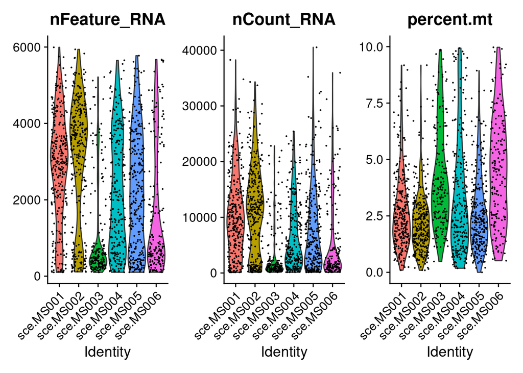

```r
qc.dir <- file.path(results.dir, 'qc')
dir.create(qc.dir)

sce.seurat[["percent.mt"]] <- PercentageFeatureSet(sce.seurat, pattern = "^mt-")
p<-VlnPlot(sce.seurat, features = c("nFeature_RNA", "nCount_RNA", "percent.mt"), ncol = 3)
ggsave(p, file = file.path(qc.dir, 'before_qc.pdf'), height = 10)
fwrite(as.data.table(table(sce.seurat@meta.data['batch'])), file = file.path(qc.dir, 'cells_before_qc.tsv'), sep = '\t')

# Subset and plot after qc
sce.seurat <- subset(sce.seurat, subset = nFeature_RNA > 100 & nFeature_RNA < 6000 & percent.mt < 10)
p<-VlnPlot(sce.seurat, features = c("nFeature_RNA", "nCount_RNA", "percent.mt"), ncol = 3)
ggsave(p, file = file.path(qc.dir, 'after_qc.pdf'), height = 10)
fwrite(as.data.table(table(sce.seurat@meta.data['batch'])), file = file.path(qc.dir, 'cells_after_qc.tsv'), sep = '\t')
p
```

# Standard Seurat pipeline

## Initial clustering

Here, a standard Seurat preprocessing pipeline is run with Data normalization, Variable Feature Extraction, PCA, Neighborhood embedding and UMAP representation.

```r
sce.seurat <- NormalizeData(object = sce.seurat)
sce.seurat <- FindVariableFeatures(object = sce.seurat)
sce.seurat <- ScaleData(object = sce.seurat)
sce.seurat <- RunPCA(object = sce.seurat)
sce.seurat <- FindNeighbors(object = sce.seurat, k.param = 20)
sce.seurat <- FindClusters(object = sce.seurat)
```

```
## Modularity Optimizer version 1.3.0 by Ludo Waltman and Nees Jan van Eck
##
## Number of nodes: 1473
## Number of edges: 41812
##
## Running Louvain algorithm...
## Maximum modularity in 10 random starts: 0.8728
## Number of communities: 13
## Elapsed time: 0 seconds
```

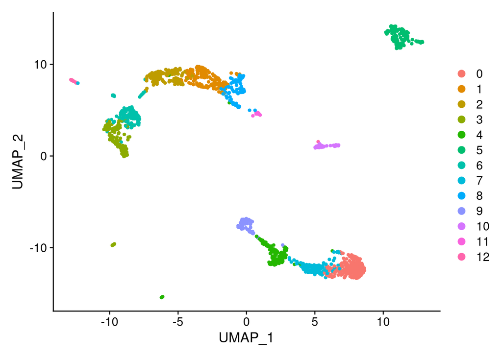

```r
sce.seurat <- RunUMAP(object = sce.seurat, dims = 1:50)
DimPlot(object = sce.seurat, reduction = "umap")
```

### Visualizing the clustering

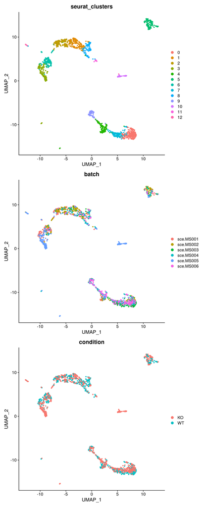

```r
standard.plots<-DimPlot(object = sce.seurat, group.by   = c('seurat_clusters', 'batch', 'condition'))
ggsave(standard.plots, file = file.path(qc.dir, 'embeddings_before_harmony.pdf'), width = 25, units = 'cm', height = 10)
standard.plots+ plot_layout(ncol = 1)
```

There is no massive batch effect in the data, if any, there is a slight problem width SCE.005/ cluster 3. Since the other analysis used batch integration it is used here as well to avoid to strong differences.

## To conform with prior analysis integrate the batches

We use harmony to integrate the batches.

```r
sce.seurat <- RunHarmony(sce.seurat, group.by.vars = "batch")
sce.seurat <- RunUMAP(sce.seurat, reduction = "harmony", dims = 1:30)
sce.seurat <- FindNeighbors(sce.seurat, reduction = "harmony", dims = 1:30) %>% FindClusters()
```

```
## Modularity Optimizer version 1.3.0 by Ludo Waltman and Nees Jan van Eck
##
## Number of nodes: 1473
## Number of edges: 49120
##
## Running Louvain algorithm...
## Maximum modularity in 10 random starts: 0.8656
## Number of communities: 12
## Elapsed time: 0 seconds
```

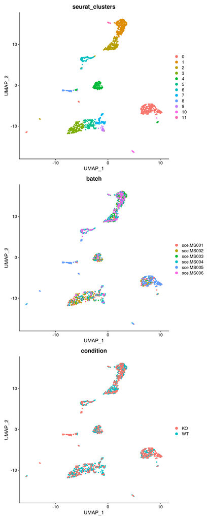

```r
harmony.plot<-DimPlot(object = sce.seurat, group.by   = c('seurat_clusters', 'batch', 'condition'))
ggsave(harmony.plot, file = file.path(qc.dir, 'embeddings_after_harmony.pdf'), width = 25, units = 'cm', height = 10)
harmony.plot+ plot_layout(ncol = 1)
```

# Marker gene set base embedding

In order to annotate the clusters to phenotypes from the literature, we use known gene sets and score the data using the ModuleScore function of Seurat. There are several gene sets in the literature, and we use several to see which one fits the best.

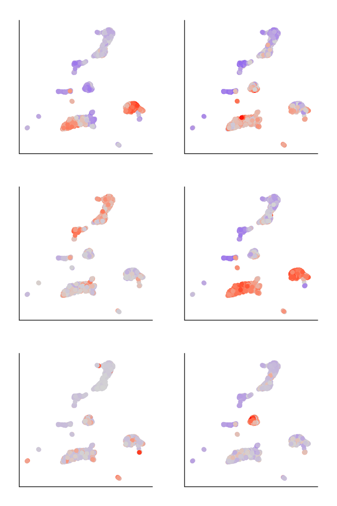

```r
markers<-fread(marker_file, header=FALSE)

iCAF <- markers[V2 == 'iCAF']$V1
myCAF<- markers[V2 == 'myCAF']$V1
apCAF<- markers[V2 == 'apCAF']$V1

mCAF<- markers[V2 == 'mCAF']$V1
dCAF<- markers[V2 == 'dCAF']$V1
vCAF<- markers[V2 == 'vCAF']$V1

score<-list(iCAF, myCAF, apCAF, mCAF, dCAF, vCAF)
names(score)<-c('iCAF', 'myCAF', 'apCAF', 'mCAF', 'dCAF', 'vCAF')
sce.seurat <- AddModuleScore(
  object = sce.seurat,
  features = score,
  name =c('iCAF', 'myCAF', 'apCAF', 'mCAF', 'dCAF', 'vCAF'),
  ctrl = 100)

p1<- FeaturePlot(sce.seurat, c('iCAF1'), pt.size= 3)+scale_color_gradient2(low = 'blue', mid = 'lightgrey',high = 'red', midpoint = 0) +ggtitle("")+xlab("")+ylab("")+theme(axis.ticks = element_blank(), axis.text = element_blank(), aspect.ratio = 1)+ guides(color="none")

p3<- FeaturePlot(sce.seurat, c('myCAF2'), pt.size= 3)+scale_color_gradient2(low = 'blue', mid = 'lightgrey',high = 'red', midpoint = 0)+ggtitle("")+xlab("")+ylab("")+theme(axis.ticks = element_blank(), axis.text = element_blank(), aspect.ratio = 1)+ guides(color="none")+ coord_fixed(ratio = 1)

p4<- FeaturePlot(sce.seurat, c('apCAF3'), pt.size= 3)+scale_color_gradient2(low = 'blue', mid = 'lightgrey',high = 'red', midpoint = 0)+ggtitle("")+xlab("")+ylab("")+theme(axis.ticks = element_blank(), axis.text = element_blank(), aspect.ratio = 1)+ guides(color="none")+ coord_fixed(ratio = 1)


p2<- FeaturePlot(sce.seurat, c('mCAF4'), pt.size= 3)+scale_color_gradient2(low = 'blue', mid = 'lightgrey',high = 'red', midpoint = 0)+ggtitle("")+xlab("")+ylab("")+theme(axis.ticks = element_blank(), axis.text = element_blank(), aspect.ratio = 1)+ guides(color="none")+ coord_fixed(ratio = 1)

p5<- FeaturePlot(sce.seurat, c('dCAF5'), pt.size= 3)+scale_color_gradient2(low = 'blue', mid = 'lightgrey',high = 'red', midpoint = 0)+ggtitle("")+xlab("")+ylab("")+theme(axis.ticks = element_blank(), axis.text = element_blank(), aspect.ratio = 1)+ guides(color="none")+ coord_fixed(ratio = 1)

p6<- FeaturePlot(sce.seurat, c('vCAF6'), pt.size= 3)+scale_color_gradient2(low = 'blue', mid = 'lightgrey',high = 'red', midpoint = 0)+ggtitle("")+xlab("")+ylab("")+ coord_fixed(ratio = 1)+theme(axis.ticks = element_blank(), axis.text = element_blank(), aspect.ratio = 1)+ guides(color="none")



cellstates.dir<-file.path(results.dir, 'cellstates')
dir.create(cellstates.dir)

pp<-p1+p3+p4+p2+p5+p6+ plot_layout(ncol = 2)
ggsave(pp, file = file.path(cellstates.dir, 'cellstates.pdf'), height = 30, units = 'cm')
pp
```

```r
pnames<-c('iCAF', 'myCAF', 'apCAF', 'mCAF', 'dCAF', 'vCAF')
i<-1
for (p in list(p1, p2, p3, p4, p5, p6)){
  ggsave(p, file = file.path(cellstates.dir, paste0(pnames[i], '.pdf')), height = 8, width = 8)
   ggsave(p, file = file.path(cellstates.dir, paste0(pnames[i], '.png')), height = 8, width = 8)
  i<-i+1
}
```

# Differential abundance using DASeq

In order to identify whether the proportion of different cell populations shift between WT and KO, we run differential abundance analysis using DASEQ. DASeq is able to identify groups of cells which contain systematically more cells of one of the conditions. Here, DAseq is set up such that low scores in the DASeq result correspond to higher number of WT cells and high scores indicate higher numbers of KO cells. The analysis here follows the standard procedure as indicated in the tutorial: https://klugerlab.github.io/DAseq/articles/tutorial.html

## Set up data

```r
daseq.dir<-file.path(results.dir, 'daseq')
dir.create(daseq.dir)

sce.pca<-sce.seurat@reductions$pca@cell.embeddings
sce.labels<-rownames(sce.pca)

lables.WT<- rownames(sce.seurat@meta.data[sce.seurat$condition=='WT' ,])
lables.KO<- rownames(sce.seurat@meta.data[sce.seurat$condition=='KO' ,])

da_cells <- getDAcells(
  X = sce.pca,
  cell.labels = sce.labels,
  labels.1 = lables.WT,
  labels.2 = lables.KO,
  k.vector = seq(15, 500, 50),
  plot.embedding = sce.seurat@reductions$umap@cell.embeddings[,1:2]
)
```

```
## Calculating DA score vector.
## Running GLM.
## Test on random labels.
## Setting thresholds based on permutation
```

```r
da_cells <- updateDAcells(
  X = da_cells, pred.thres = c(-0.8,0.8),
  plot.embedding = sce.seurat@reductions$umap@cell.embeddings[,1:2]
)

p<-da_cells$da.cells.plot
ggsave(p, file = file.path(daseq.dir, 'daseq_cells.pdf'))
```

## Show the statistically enriched regions

```r
da_regions <- getDAregion(
  X = sce.pca,
  da.cells = da_cells,
  cell.labels = sce.labels,
  labels.1 = lables.WT,
  labels.2 = lables.KO,
  resolution = 0.01,
  min.cell = 15,
  plot.embedding = sce.seurat@reductions$umap@cell.embeddings[,1:2],
  size= 3
)
```

```
## Removing 4 DA regions with cells < 15.
```

```r
tab<-da_regions$DA.stat
fwrite(tab, file.path(daseq.dir, 'daseq_stats.tsv'))
tab
```

```
##        DA.score pval.wilcoxon   pval.ttest
## [1,]  0.9351875  5.369764e-14 7.701717e-15
## [2,]  1.0000000  1.347801e-12 2.272813e-13
## [3,] -1.0000000  5.623935e-06 1.166155e-05
```

There are 3 regions which show a statistical enrichment of either WT or KO cell types.

## Make plots

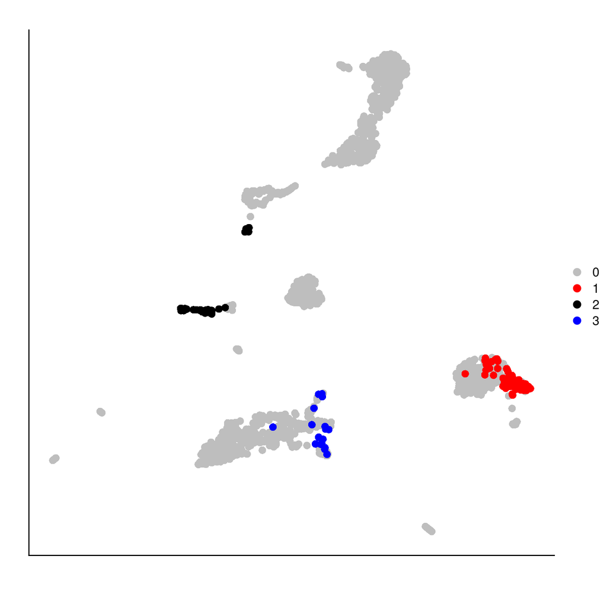

```r
okabe <- c("grey", "red", "black", "blue")
pp<-da_regions$da.region.plot+scale_color_manual (values  = okabe)+xlab("")+ylab("")+theme(axis.ticks = element_blank(), axis.text = element_blank(), aspect.ratio = 1)

pp
```

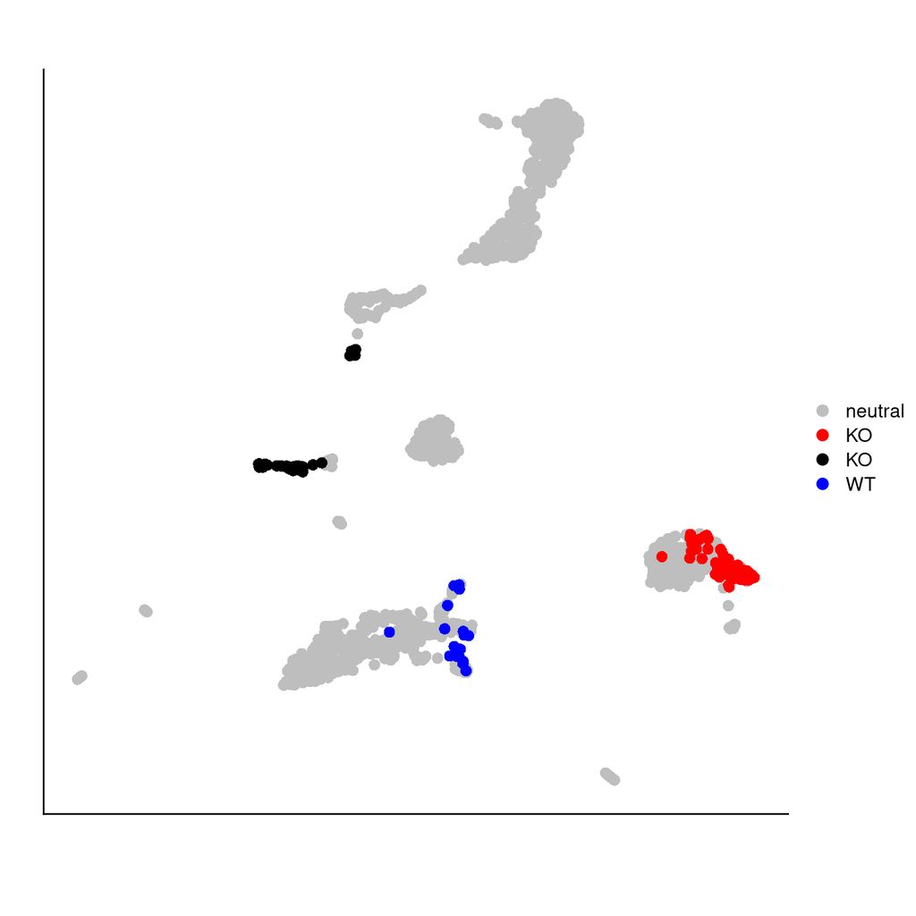

```r
ggsave(pp, file = file.path(daseq.dir, 'daseq_regions_wiht_number.pdf'), height = 8, width = 9)
ggsave(pp, file = file.path(daseq.dir, 'daseq_regions_wiht_number.png'), height = 8, width = 9, bg = "white")

pp<-pp+scale_color_manual(labels = c("neutral", "KO", "KO", 'WT'), values  = okabe)+xlab("")+ylab("")+theme(axis.ticks = element_blank(), axis.text = element_blank())+ coord_fixed(ratio = 1)
ggsave(pp, file = file.path(daseq.dir, 'daseq_regions_wiht_label.pdf'), height = 8, width = 9)
pp
```

We see that the black KO region corresponds to a cluster which contains mainly M005 cells. It is hard to evaluate whether this group of cells represents an artifact or a genuine discovery. Here, the choice was made to disregard this cluster from the analysis, because it may not represent a generalizable discovery for all KO mice.

## Find markers for DA regions

Find representative genes for the regions.

```r
STG_markers <- STGmarkerFinder(
  X = sce.seurat@assays$RNA@data,
  da.regions = da_regions,
  lambda = 1.5, n.runs = 5, return.model = T,
  python.use = python_env,
  GPU = ''
)
```

[output not shown]

[output cut: 95 more lines]

[output not shown]

```r
dp<-DimPlot(sce.seurat, split.by = 'batch' , ncol = 3)
ggsave(dp, file = file.path(daseq.dir, 'batches.split.pdf'))

label<-function(x, threshold){
  if (x>threshold){
    return ('up')
  }
  else if(x< -threshold) {
    return ('down')
  }
  else{
    return('neutral')
  }
}


sce.seurat$da.pred<-da_cells$da.pred
sce.seurat$da.pred.bin<-round(da_cells$da.pred)
sce.seurat$da.pred.bin.label<-sapply(sce.seurat$da.pred, function(x) label(x, 0.8))



da_clusters<-list(c(0), c(8), c(7,9))
for (i in 1:length(STG_markers$da.markers)){
  region_2<-as.data.table(STG_markers$da.markers[[as.character(i)]])
  region_2<-region_2[p_value<0.01]
  print(region_2)
  fwrite(region_2, file = file.path(daseq.dir, paste0('region_', i,'.tsv')))
  Idents(sce.seurat)<-'seurat_clusters'
  sce.sub<-subset(sce.seurat, subset = seurat_clusters %in% da_clusters[[i]] )
  pv<-VlnPlot(sce.sub, features = region_2[1:10]$gene , group.by ='da.pred.bin.label' )
  ggsave(pv, file = file.path(daseq.dir, paste0('top_region_', i,'.pdf')), width = 20, height = 30, units = 'cm')
}
```

```
##        gene avg_logFC      p_value
##   1:   Apod 3.6087416 4.400616e-61
##   2:   Osr2 3.3450601 3.869057e-56
##   3:   Gas1 2.8932365 2.630517e-54
##   4:    Fst 3.2248433 6.781890e-54
##   5: Ctla2a 4.5678976 9.968275e-50
##  ---
## 306:    C1d 0.9995466 7.453457e-03
## 307:  Gstm5 1.0829472 8.089937e-03
## 308:  Blvrb 1.2124816 8.273648e-03
## 309:  Glud1 0.4116755 8.820157e-03
## 310:  Strn3 0.4098708 9.151682e-03
```

```
##               gene   avg_logFC       p_value
##   1:        Trim29  6.44231783 9.611054e-227
##   2:          Pkp1  5.49426401 6.880149e-190
##   3:        Celsr2  5.80215778 5.733870e-186
##   4:          Dsc3  5.18794218 8.509447e-176
##   5: 1190003J15Rik  5.61830914 4.003599e-172
##  ---
## 466:        Ppp3ca  0.34634591  6.926656e-03
## 467:          Tpm2  0.08361507  7.070530e-03
## 468:          Junb -0.22190389  7.584926e-03
## 469:         Anxa2 -0.19999891  8.417456e-03
## 470:         Rn45s -0.10410975  9.372423e-03
```

```
##        gene  avg_logFC      p_value
##   1:  Mmp10  3.2565049 1.300282e-25
##   2: Col6a4  3.2625322 1.086675e-20
##   3:   Fbn2  3.7727421 1.072979e-18
##   4:  Foxl1  3.5903656 2.891393e-18
##   5:  Inhba  3.0842734 7.246118e-18
##  ---
## 187:   Pim1 -1.4133427 8.787636e-03
## 188: Ndufs3  1.2077530 9.362957e-03
## 189:  Acta2  0.7538293 9.619177e-03
## 190:  Eif3a  0.6812234 9.756517e-03
## 191: Cox6a1  0.5890282 9.906662e-03
```

```r
mdf<-as.data.table(sce.seurat@meta.data)
summary.da<- mdf[, .N, by = c( 'seurat_clusters','condition', 'da.pred.bin.label')] %>% arrange(seurat_clusters)
summary.da<-as.data.table(summary.da)
fwrite(summary.da, file.path(daseq.dir, 'summary_daseq.tsv'), sep = '\t')
```

# Differential Gene expression global WT vs. KO

To get some general understanding we run a differential analysis of all WT vs all KO cells.

```r
de.dir<-file.path(results.dir, 'deg')
dir.create(de.dir)
Idents(sce.seurat)<-'condition'

m<-FindMarkers(sce.seurat, ident.1 = 'WT', ident.2 = 'KO')
genes<-rownames(m)
m<-as.data.table(m)
m$gene<-genes

fwrite(m[p_val_adj<0.01], file = file.path(de.dir, 'DEG_WT_KO_p0.01.tsv'), sep = '\t')
vln<-VlnPlot(sce.seurat, features = m$gene[1:10])

ggsave(vln, file = file.path(de.dir, 'vln_plots_top10.pdf'))
```

## Make plots and assign tentative phenotypes

In order to characterize cell states further, it is useful to assign tentative labels to each group, even if a categorical cell type classification/definition most likely does not reflect reality. Based on the cell scores above, we used the mcaf, icaf, apcaf definition also used by Elyada et. al to characterize our cells. Additionally a cluster of vCAF cells has been identified.

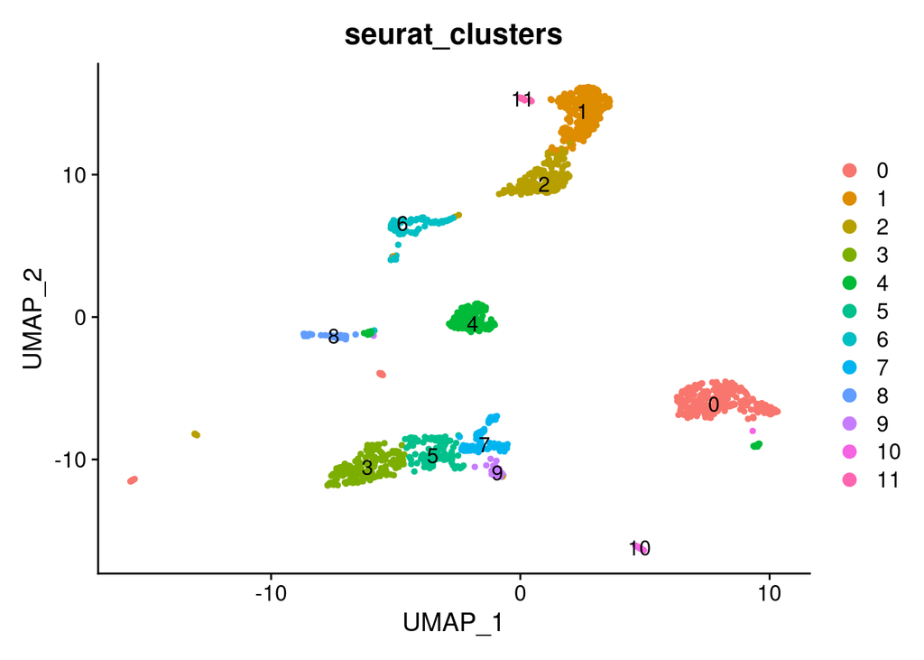

```r
##############################################################################
## 6. grouped UMAP
numbered.umap<-DimPlot(sce.seurat, group.by = 'seurat_clusters', label = TRUE)
numbered.umap
```

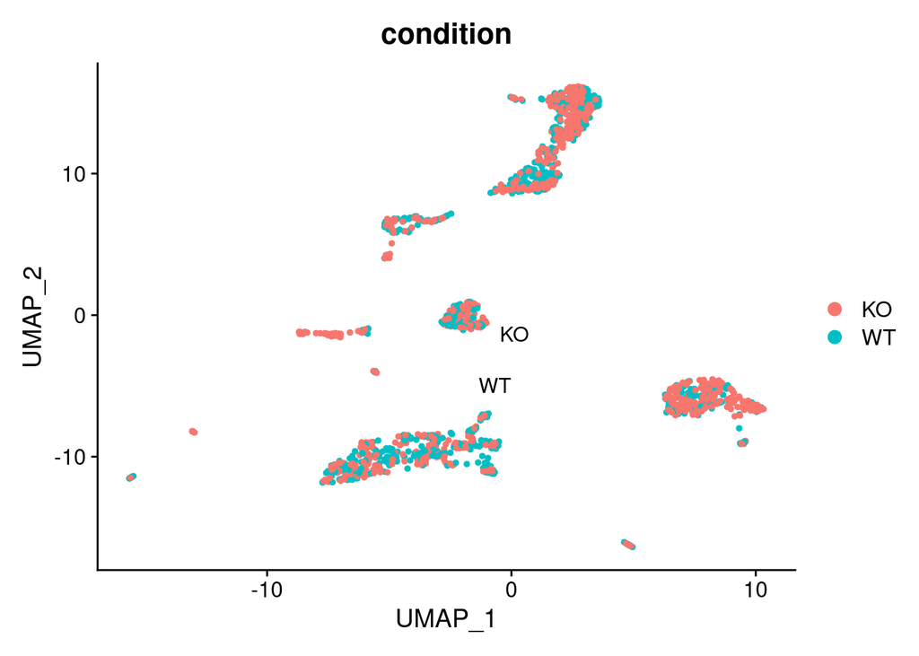

```r
ggsave(numbered.umap, file = file.path(de.dir, 'umap_with_number.pdf'))

numbered.umap<-DimPlot(sce.seurat, group.by = 'condition', label = TRUE)
numbered.umap
```

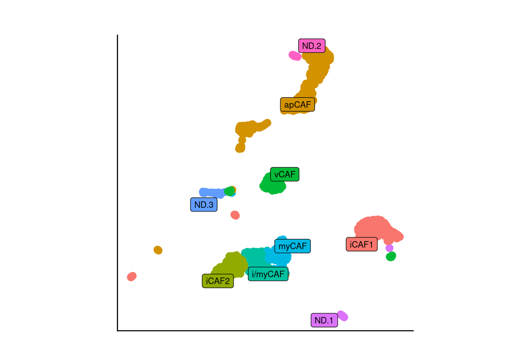

```r
ggsave(numbered.umap, file = file.path(de.dir, 'umap_with_condition.pdf'))

## Assign labels.
sce.seurat$phenotype<-recode(sce.seurat$seurat_clusters, '0' = 'mCAF-iCAF', '1' = 'apCAF', '2'= 'apCAF', '3' = 'mCAF-iCAF', '4' = 'vCAF', '5' = 'mCAF-iCAF', '6' = 'apCAF' ,'7' = 'mCAF-iCAF', '8'='??-0', '9'='mCAF-iCAF', '10' = '??-1', '11' = 'apCAF')
sce.seurat$phenotype_new<-recode(sce.seurat$seurat_clusters, '0' = 'iCAF1', '1' = 'apCAF', '2'= 'apCAF', '3' = 'iCAF2', '4' = 'vCAF', '5' = 'i/myCAF', '6' = 'apCAF' ,'7' = 'myCAF', '8'='ND.3', '9'='myCAF', '10' = 'ND.1', '11' = 'ND.2')

##Plot
labelle.umap<-DimPlot(sce.seurat, group.by = 'phenotype', label = TRUE)
ggsave(labelle.umap, file = file.path(de.dir, 'labelled_umap.pdf'))

labelle.umap<-DimPlot(sce.seurat, group.by = 'phenotype_new', label = TRUE, label.size = 3, label.box = T, repel = T, pt.size = 3)+xlab("")+ylab("")+theme(axis.text = element_blank(), axis.ticks = element_blank())+ggtitle("")+xlab("")+ylab("")+theme(axis.ticks = element_blank(), axis.text = element_blank(), aspect.ratio = 1)+ guides(color="none")
labelle.umap
```

```r
ggsave(labelle.umap, file = file.path(de.dir, 'labelled_umap.pdf'), height = 8, width = 8)
ggsave(labelle.umap, file = file.path(de.dir, 'labelled_umap.png'), height = 8, width = 8)
```

## Phenotype scores.

The ModuleScores calculated above shown for each of the cell phenotype groups.

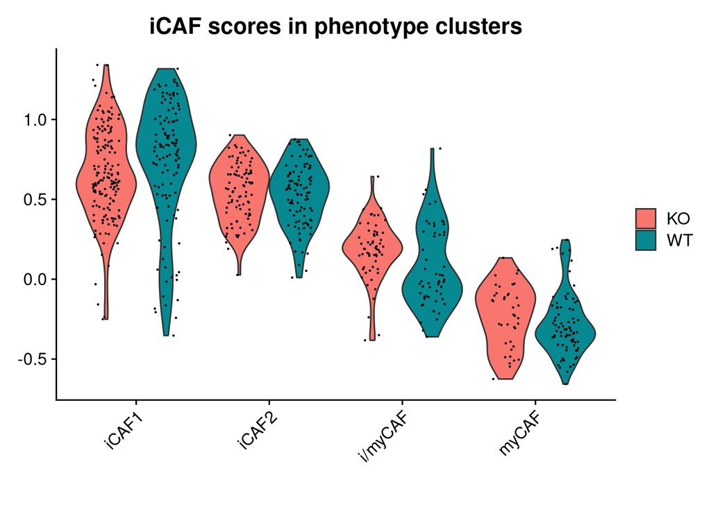

```r
Idents(sce.seurat)<-'phenotype_new'
icaf1.score<-VlnPlot(sce.seurat, features = 'iCAF1', idents = c('iCAF1', 'iCAF2', 'i/myCAF','myCAF'),  split.by = 'condition')+ggtitle('iCAF scores in phenotype clusters')+xlab('')
icaf1.score
```

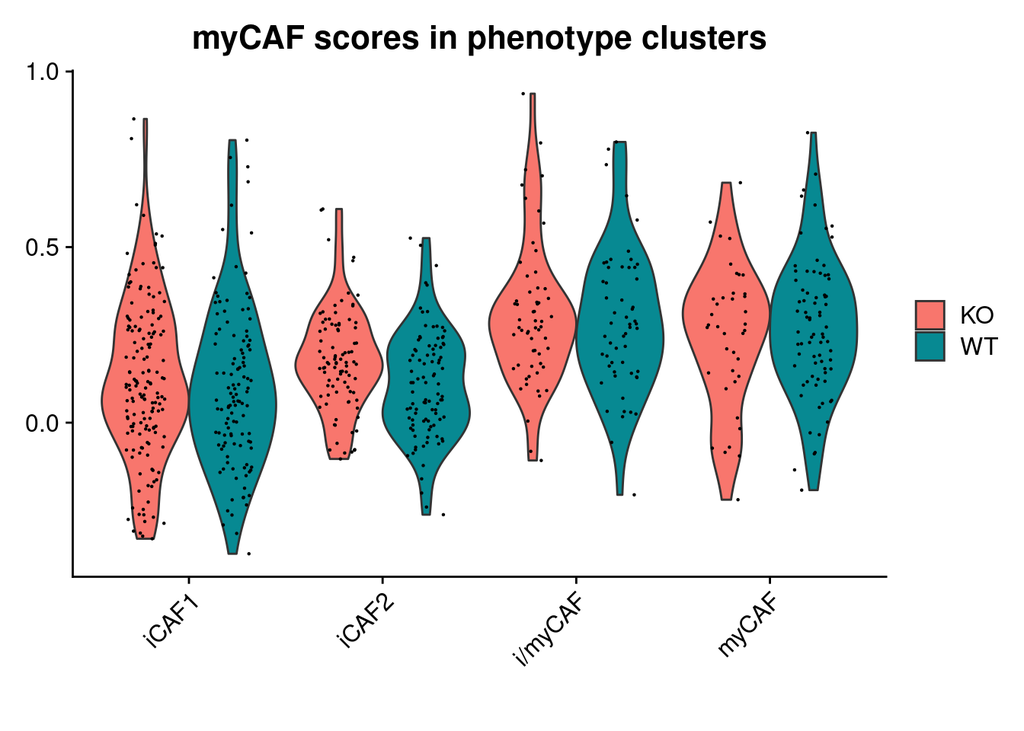

```r
ggsave(icaf1.score, file = file.path(cellstates.dir, 'iCAF_scores_in_pops.pdf'), width = 30, height = 10, units = 'cm')

Idents(sce.seurat)<-'phenotype_new'
mycaf.score<-VlnPlot(sce.seurat, features = 'myCAF2', idents = c('iCAF1', 'iCAF2', 'i/myCAF','myCAF'),  split.by = 'condition') +ggtitle('myCAF scores in phenotype clusters')+xlab('')
mycaf.score
```

```r
ggsave(mycaf.score, file = file.path(cellstates.dir, 'myCAF_scores_in_pops.pdf'), width = 30, height = 10, units = 'cm')
```

## Correlation between scores by Seurat cluster

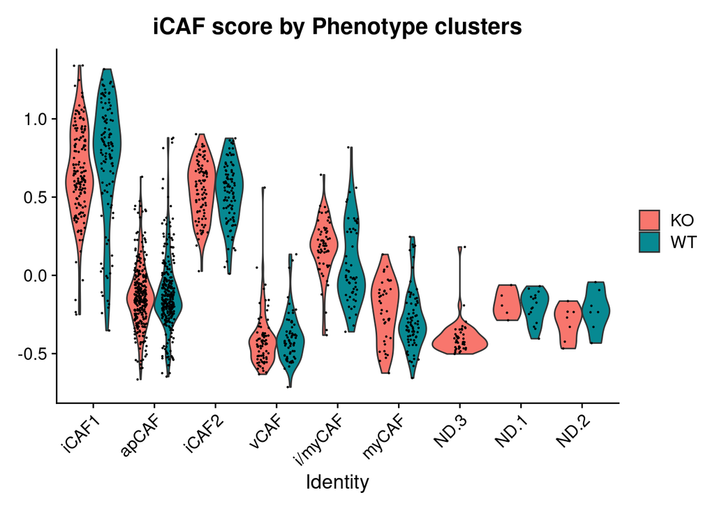

```r
meta<-as.data.table(sce.seurat@meta.data)

for (g in list(c(7,9), c(3,5), c(0))){
  for(phe in c('WT', 'KO')){
    co<-cor.test(meta[condition == phe & seurat_clusters %in% g]$iCAF1, meta[condition == phe & seurat_clusters %in% g]$myCAF2)
    chars<-capture.output(co)
    fileConn<-file(file.path(cellstates.dir, paste0('corr.', paste(g, collapse = ''), '.', phe, '.txt')))
    writeLines(chars, con =fileConn )
    close(fileConn)
  }
}

scatter<-ggplot(meta, aes(iCAF1, myCAF2))+geom_point()+facet_wrap(c("phenotype_new", "condition"), scales = 'free')
ggsave(scatter, file = file.path(cellstates.dir, 'scatter_correlations.pdf'), height = 30, width = 30, units = 'cm')



Idents(sce.seurat)<-'seurat_clusters'
icaf.score<-VlnPlot(sce.seurat, features = 'iCAF1', split.by   = 'condition')+ggtitle('iCAF score by Leiden clusters')
ggsave(icaf.score, file = file.path(cellstates.dir, 'iCAF_scores_by_seurat.pdf'))


Idents(sce.seurat)<-'phenotype_new'
icaf.score<-VlnPlot(sce.seurat, features = 'iCAF1', split.by   = 'condition')+ggtitle('iCAF score by Phenotype clusters')
icaf.score
```

```r
ggsave(icaf.score, file = file.path(cellstates.dir, 'iCAF_scores_by_phenotype.pdf'))


summary_table<-table(sce.seurat@meta.data[, c("condition", "phenotype_new")])
fwrite(summary_table, file = file.path(de.dir, 'cells_per_pop.tsv'), sep= '\t')
```

# What are these clusters? ==> DEG between clusters.

## Cluster iCAF1 vs all other iCAF/myCAF

```r
Idents(sce.seurat)<-'phenotype_new'
mm<-FindMarkers(sce.seurat, ident.1 =  'iCAF1', ident.2 = c('myCAF',  'i/myCAF', 'iCAF2'))
g<-rownames(mm)
mm<-as.data.table(mm)
mm$genes<-g
fwrite(mm, file = file.path(de.dir, 'cluster0_vs_restofmCAFiCAF.tsv'), sep = '\t')
```

## Cluster mycaf vs i/myCAF

```r
Idents(sce.seurat)<-'phenotype_new'
mm<-FindMarkers(sce.seurat, ident.1 =  'i/myCAF' , ident.2 = c('myCAF'))
g<-rownames(mm)
mm<-as.data.table(mm)
mm$genes<-g
fwrite(mm, file = file.path(de.dir, 'clusterimyCAF_vs_clustermyCAF.tsv'), sep = '\t')
```

# 9. Add tests between WT and KO within clusters.

```r
all_genes<-c()
Idents(sce.seurat)<-'phenotype_new'
phenotypes<-c('myCAF',  'i/myCAF', 'iCAF2', 'vCAF', 'iCAF1', 'apCAF')
for (pop in phenotypes){
  sub.seurat<-subset(sce.seurat, subset = phenotype_new == pop)
  Idents(sub.seurat)<-'condition'
  m<-FindMarkers(sub.seurat, ident.1 = 'WT', ident.2 = 'KO')
  genes<-rownames(m)
  m<-as.data.table(m)
  m$genes<-genes
  m<-m[p_val_adj < 0.05]

  pop <- gsub('/', '_', pop)
  fwrite(m, file = file.path(de.dir, paste0(pop, 'DEG_WT_KO_p0.05.tsv')), sep = '\t')
  sub.dir<-file.path(de.dir, pop)
  dir.create(sub.dir)
  for(g in m$genes){
    pl<-VlnPlot(sub.seurat, features = g)
    ggsave(pl, file = file.path(sub.dir, paste0(g, '.pdf')))
  }
  all_genes<-c(all_genes, m$genes)
}
```

# Save data object

```r
saveRDS(sce.seurat, file = file.path(results.dir,  'seurat.Rds'), compress = F)
sce.seurat <- readRDS(file.path(results.dir,  'seurat.Rds'))
```

## Check transcription factor activity

```r
tf.dir<-file.path(results.dir, 'tf-target')
dir.create(tf.dir)
net <- get_collectri(organism='mouse', split_complexes=FALSE)
fwrite(as.data.table(net), file = file.path(tf.dir, 'collectri.tsv'), sep = '\t')
net1<- net %>% filter(source =='Zeb1')
net2<- net %>% filter(source %in% net1$target)



apcaf.de<-fread(file.path(de.dir, 'apCAFDEG_WT_KO_p0.05.tsv'))
vcaf.de<-fread(file.path(de.dir, 'vCAFDEG_WT_KO_p0.05.tsv'))
icafmcaf.de.0<-fread(file.path(de.dir, 'iCAF1DEG_WT_KO_p0.05.tsv'))
icafmcaf.de.35<-fread(file.path(de.dir, 'i_myCAFDEG_WT_KO_p0.05.tsv'))
icafmcaf.de.79<-fread(file.path(de.dir, 'myCAFDEG_WT_KO_p0.05.tsv'))
icafmcaf.de.1<-fread(file.path(de.dir, 'iCAF2DEG_WT_KO_p0.05.tsv'))

intersect(net1$target, apcaf.de$genes)
```

```
## character(0)
```

```r
intersect(net1$target, icafmcaf.de.0$genes)
```

```
## [1] "Cdh13"
```

```r
p.prim<-VlnPlot(sce.seurat, features =intersect(net1$target, icafmcaf.de.0$genes), split.by = 'condition')
ggsave(p.prim, file = file.path(tf.dir, 'primary_targets_in_iCAFmCAF0.pdf'))

intersect(net1$target, vcaf.de$genes)
```

```
## character(0)
```

```r
intersect(net2$target, apcaf.de$genes)
```

```
## character(0)
```

```r
intersect(net2$target, icafmcaf.de.0$genes)
```

```
##  [1] "C3"       "Egr1"     "Cd44"     "Fos"      "Krt14"    "Zeb1"
##  [7] "Dhcr24"   "Des"      "Fosb"     "Lcn2"     "Serpinh1" "Nt5e"
## [13] "Hk2"
```

```r
intersect(net2$target, icafmcaf.de.1$genes)
```

```
## character(0)
```

```r
intersect(net2$target, icafmcaf.de.35$genes)
```

```
## character(0)
```

```r
intersect(net2$target, icafmcaf.de.79$genes)
```

```
## character(0)
```

```r
intersect(net2$target, vcaf.de$genes)
```

```
## [1] "S100a6"
```

```r
targets.targets.zeb1.icaf<-VlnPlot(sce.seurat, features = intersect(net2$target, icafmcaf.de.0$genes), split.by = 'condition')
ggsave(targets.targets.zeb1.icaf, file = file.path(tf.dir, 'targets_of_targets_of_zeb1_icaf_mcaf_0.pdf'), height = 60, width = 40, units = 'cm', limitsize = F)

targets.targets.zeb1.vacf<-VlnPlot(sce.seurat, features = intersect(net2$target, vcaf.de$genes), split.by = 'condition')
ggsave(targets.targets.zeb1.vacf, file = file.path(tf.dir, 'targets_of_targets_of_zeb1_vCAF.pdf'), height = 60, width = 40, units = 'cm', limitsize = F)
```